# Bimodal Covariates and the Estimated MCCE

Brenton Kenkel — PSCI 8357

February 11, 2016

In class today, I mentioned that the estimated standard error of the MCCE for a quadratic relationship tends to be smallest for values close to the sample mean. This raised the question of whether this holds true with a bimodal covariate—if there’s relatively little data near the sample mean, is the standard error of the estimated MCCE lowest there? This note will run a little simulation to find out.

First we need to know how to simulate a bimodal covariate. Assume there is a “left” distribution with mean $-3$ and a “right” distribution with mean $3$, and each observation has a 50-50 chance of being chosen from the left or the right.

```r
n_obs <- 100
x_left <- rnorm(n_obs, mean = -3)
x_right <- rnorm(n_obs, mean = 3)
is_left <- rbinom(n_obs, size = 1, prob = 0.5)
x <- is_left * x_left + (1 - is_left) * x_right
```

Let’s check that the resulting distribution is indeed bimodal.

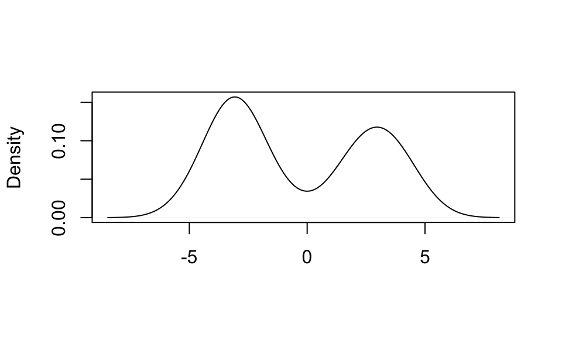

```r
plot(density(x), xlab = "", main = "")
```

OK, so now let’s generate a response variable according to a quadratic model:
$$Y = 1 + \beta_1 X + \beta_2 X^2 + \epsilon.$$
As in class, we’ll assume that the expected response is greater at the extremes (e.g., people with extreme viewpoints are more likely to vote). We’ll also assume a slight positive trend overall (e.g., conservatives are more likely to vote, all else equal).

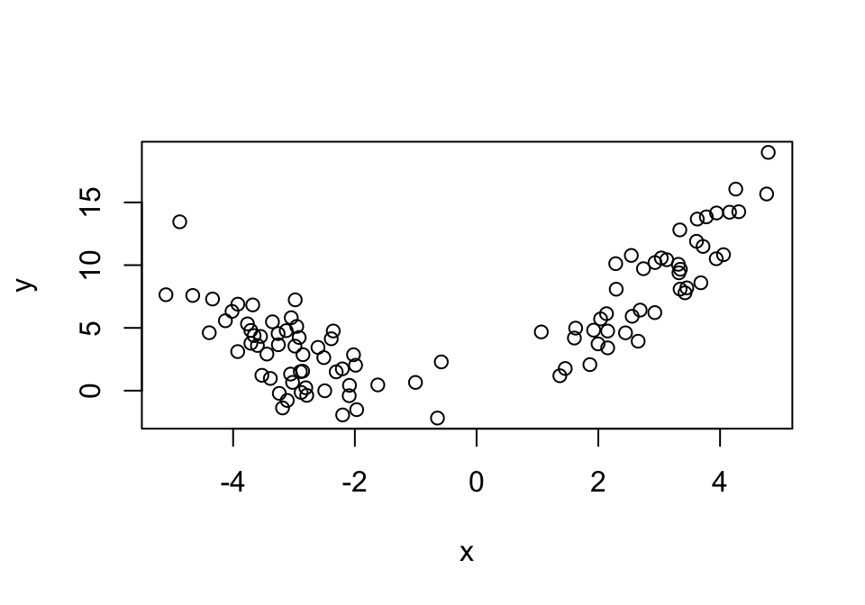

```r
y <- 1 + x + 0.5 * x^2 + rnorm(n_obs, sd = 2)
plot(x, y)
```

We can fit a quadratic model and use it to estimate the pointwise marginal changes in conditional expectation,
$$\text{MCCE}(X) = \beta_1 + 2 \beta_2 X.$$

```r
fit_quadratic <- lm(y ~ x + I(x^2))
summary(fit_quadratic)
```

```
##
## Call:
## lm(formula = y ~ x + I(x^2))
##
## Residuals:
##    Min     1Q Median     3Q    Max
## -4.396 -1.858  0.153  1.477  4.905
##
## Coefficients:
##             Estimate Std. Error t value Pr(>|t|)
## (Intercept)   0.7792     0.4163    1.87    0.064
## x             0.9781     0.0659   14.85   <2e-16
## I(x^2)        0.5272     0.0371   14.20   <2e-16
##
## Residual standard error: 2.04 on 97 degrees of freedom
## Multiple R-squared:  0.804,  Adjusted R-squared:   0.8
## F-statistic:  199 on 2 and 97 DF,  p-value: <2e-16
```

To estimate the MCCE function, we’ll calculate the estimated MCCE for each point in a grid of potential values of $X$.

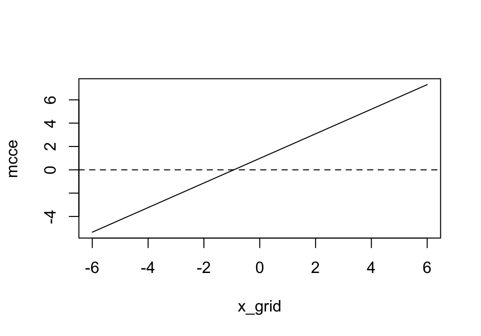

```r
x_grid <- seq(-6, 6, length.out = 100)
beta_1 <- coef(fit_quadratic)["x"]
beta_2 <- coef(fit_quadratic)["I(x^2)"]
mcce <- beta_1 + 2 * beta_2 * x_grid

plot(x_grid, mcce, type = "l")
abline(h = 0, lty = 2)
```

At this point we could use `vcov(fit_quadratic)` to estimate the standard error of the MCCEs. But we’re not interested in the estimated standard errors—we want the *true* standard errors. In other words, is the estimated MCCE more variable at the extremes (where more of the data lies) or near the mean of $X$ (where data is scarce)? To do this, we’ll simulate the whole process repeatedly.

```r
library("foreach")
```

```r
n_obs <- 100
x_grid <- seq(-6, 6, length.out = 100)

sim_results <- foreach (i = 1:1000, .combine = "rbind") %do% {
    ## Simulate data
    x_left <- rnorm(n_obs, mean = -3)
    x_right <- rnorm(n_obs, mean = 3)
    is_left <- rbinom(n_obs, size = 1, prob = 0.5)
    x <- is_left * x_left + (1 - is_left) * x_right
    y <- 1 + x + 0.5 * x^2 + rnorm(n_obs, sd = 2)

    ## Fit regression
    fit_quadratic <- lm(y ~ x + I(x^2))

    ## Extract coefficients and calculate MCCE for each element
    ## in the grid
    beta_1 <- coef(fit_quadratic)["x"]
    beta_2 <- coef(fit_quadratic)["I(x^2)"]
    mcce <- beta_1 + 2 * beta_2 * x_grid

    ## Return pointwise MCCEs
    mcce
}
```

Let’s take a look at the simulation results.

```r
dim(sim_results)
```

```
## [1] 1000  100
```

Each column is a value of `x_grid`, our grid of potential values of $X$. Each row is the estimated set of MCCEs from one iteration of the simulation. So to get the standard error corresponding to each value of $X$, we will take the standard deviation of each column of `sim_results`. We use `apply()` to apply the same function to each column of a matrix.

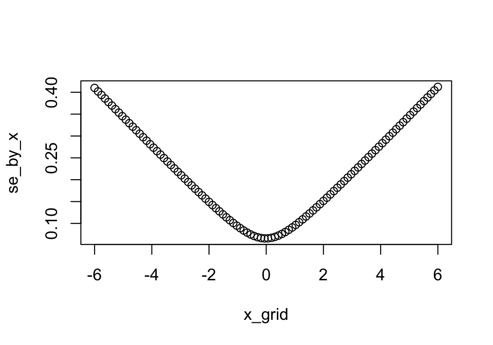

```r
se_by_x <- apply(sim_results,
                 MARGIN = 2,  # 1 for rows, 2 for columns
                 FUN = sd)
plot(x_grid, se_by_x)
```

So we see that the standard errors—the true ones, not just the estimated ones—are lowest near the mean of $X$, even though there is relatively little data there.